# Data Science Capstone - Text Prediction

C. Haen

4/17/2021

## Project Summary

The capstone project is to apply a given data set of text drawn from blogs, news and twitter in order to generate a prediction model which will predict the next desired word from user provided input. This initial milestone report presents the first step in developing such a tool, understanding the problem and the data that will be used as well as an investigation of the data normalization, data structures and prediction models that will work well for the task.

## Data Exploration

The data provided for this project is the [archived heliohost corpora from September 30, 2016](https://web-beta.archive.org/web/20160930083655/http://www.corpora.heliohost.org/aboutcorpus.html). We will be working solely with the English language files.

```r
## Packages Used In The Analysis
suppressPackageStartupMessages(library(tidyverse))
suppressPackageStartupMessages(library(textclean))
suppressPackageStartupMessages(library(quanteda))

## Reading in the data
enBlogs <- as_tibble(read_lines("./final/en_US/en_US.blogs.txt")) %>%
    mutate(source = "Blogs") %>% select(source, text = value)
enNews <- as_tibble(read_lines("./final/en_US/en_US.news.txt")) %>%
    mutate(source = "News") %>% select(source, text = value)
enTwitter <- as_tibble(read_lines("./final/en_US/en_US.twitter.txt")) %>%
    mutate(source = "Twitter") %>% select(source, text = value)

## Merge the data and add meta information such as the source, total character
## length, and number of words.
enData <- bind_rows(enBlogs, enNews, enTwitter) %>%
    mutate(source = factor(source), length = str_length(text),
           words = str_count(text, "[[:alpha:]]+") + 1)

## Summarize and plot
summary(enData)
```

```
##      source            text               length          words
##  Blogs  : 899288   Length:4269678     Min.   :    1   Min.   :   1.00
##  News   :1010242   Class :character   1st Qu.:   44   1st Qu.:   9.00
##  Twitter:2360148   Mode  :character   Median :   88   Median :  17.00
##                                       Mean   :  134   Mean   :  25.13
##                                       3rd Qu.:  154   3rd Qu.:  29.00
##                                       Max.   :40833   Max.   :6455.00
```

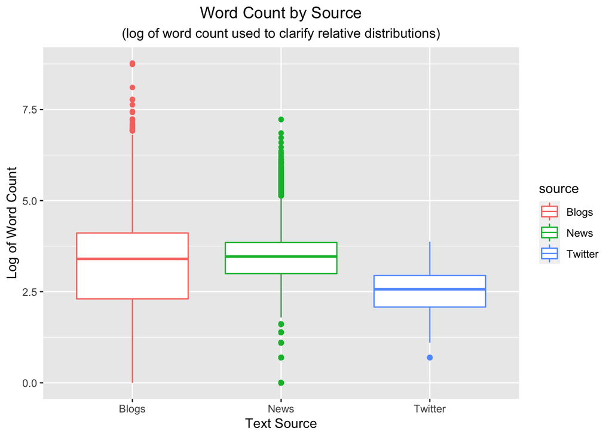

```r
ggplot(enData, aes(x = source, y = log(words), color = source)) + geom_boxplot() +
    labs(title = "Word Count by Source", subtitle = "(log of word count used to clarify relative distributions)",
         x = "Text Source", y = "Log of Word Count") +
    theme(plot.title = element_text(hjust = 0.5), plot.subtitle = element_text(hjust = 0.5))
```

## Data Normalization

In order to form a predictive model for generating next word predictions we need to tokenize and normalize our data. There are many normalization methods that need to be considered for preparation of our data in the context of our application.

Some examples of common normalization to consider:

- Capitalization - Should predictions be case sensitive?
- Punctuation & Special Characters - How will non-alpha input impact the model?
- Stop Words - By definition these add little to the context of a phrase, should they be omitted?
- Stemming/Lemmatization - Do we want to consider words such as “run”, “running”, “runs”, “ran” to be the same?
- Parts of Speech - Associating words with their relative part of speech can allow the model to include the rules of grammar into the prediction.

For many of these normalizations, it is possible that we are removing a data feature that could beneficially inform our prediction model. However, in many cases given our data set the feature is inconsistent (e.g. capitalization in Twitter) or modeling the context sufficiently complex (e.g. punctuation) that we will opt to simplify our data. Here is the normalization processing being considered at this point in the project based on research and feedback from textclean::check_text().

```r
enData <- enData %>%
    # Remove dates, times, email addresses, URLs, and HTML tags from
    # consideration. These are unlikely to be valuable for prediction.
    mutate(text = replace_date(text, replacement = " ")) %>%
    mutate(text = replace_time(text, replacement = " ")) %>%
    mutate(text = replace_email(text, replacement = " ")) %>%
    mutate(text = replace_url(text, replacement = " ")) %>%
    mutate(text = replace_html(text, symbol = FALSE)) %>%
    # Add space after a comma so that after stripping symbols words won't get
    # improperly merged together.
    mutate(text = add_comma_space(text)) %>%
    # Normalize case and remove all special characters (except apostrophe, this
    # can considerably change the interpretation of a word (e.g. "it", "it's").
    mutate(text = strip(text))
```

## Text Data Structures

Reviewing literature on word prediction, two data structures seemed to see the most widespread use.

- [n-grams](https://en.wikipedia.org/wiki/N-gram)
- [tries](https://en.wikipedia.org/wiki/Trie)

The Quanteda package proved to be the most efficient processing framework for working with text data and has simple built-in processing for n-gram data. We will utilize this package and data structure to evaluate some of the most common features with and without stop words.

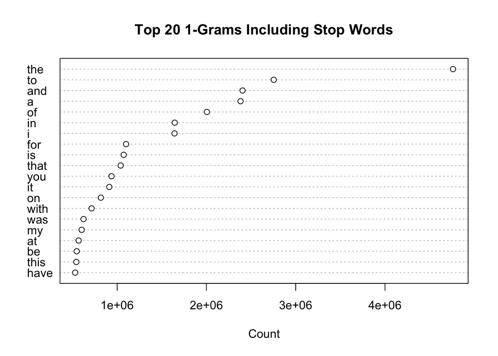

```r
## Create a corpus from the text
enCorpus <- corpus(enData$text)

## Create token groups including and excluding stop words
enTokens <- tokens(enCorpus)

## Chart features
dotchart(sort(topfeatures(enTokens %>% dfm(), 20)),
         xlab = "Count", main = "Top 20 1-Grams Including Stop Words")
```

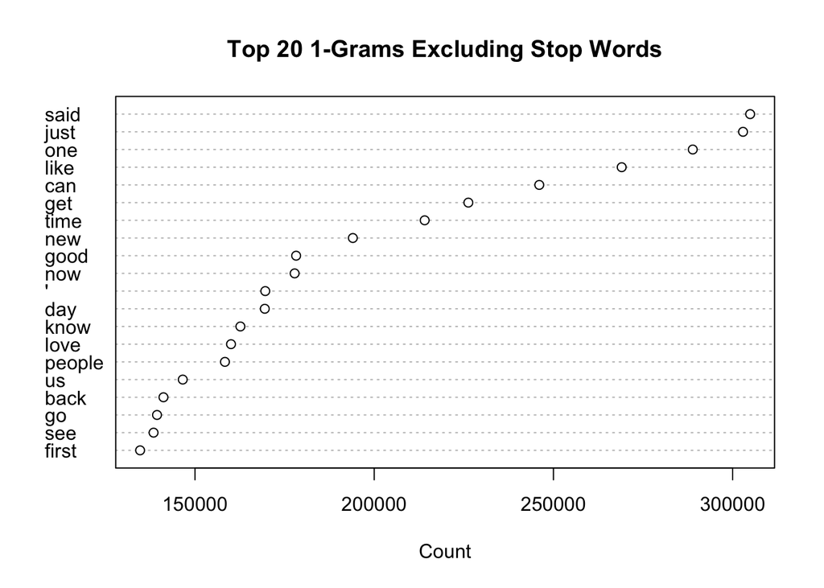

```r
dotchart(sort(topfeatures(enTokens %>% tokens_remove(c(stopwords("en"))) %>% dfm(), 20)),
         xlab = "Count", main = "Top 20 1-Grams Excluding Stop Words")
```

## Prediction Models

References to the following models for next word prediction were found during this research phase. For the next phase, the data will be separated into training, testing and validation sets and the various models will be evaluated on accuracy and complexity of implementation.

- [k-nearest neighbors](https://en.wikipedia.org/wiki/K-nearest_neighbors_algorithm)
- [markov chains](https://en.wikipedia.org/wiki/Markov_chain)
- [Katz back-off model](https://en.wikipedia.org/wiki/Katz%27s_back-off_model)
- [recurrent neural network](https://en.wikipedia.org/wiki/Recurrent_neural_network)